# Silent Failures in Automation. Pilot dataset descriptive plotting and re-design recommendations

Callum Mole

## Introduction

This document is a report for on the pre-registered experiment https://osf.io/s6vam/. The experiment examined silent failures in a highly controlled setting. Each trial starts with automated steering. In some trials a bias is introduced that causes the vehicle to veer off the road either suddenly (within 1.5 s) or gradually (~ 4 s). Participants are required to keep within the road edges and intervene if they feel that it is necessary. They complete the steering task on two bend radii, sharp (40 m) or gradual (80 m), without distraction or with an easy or difficult distraction.

#### Terminology

- The bias is to yaw-rate, so introduces error by causing the vehicle to understeer or oversteer. Effectively, the manipulation biases the mapping between steering angle - which does not change - and yaw-rate, which does change. Therefore we will henceforth call this error *Steering Angle Bias* (SAB).
- SAB is introduced in *all* trials, though in half the trials the SAB is not large enough to cause the vehicle to leave the road (though there will be some drift). It is confusing to call the ‘stay on road’ trials ‘no failure’ trial (or ‘None’ failure type). Instead, the levels of Failure Type will be *Sudden* (rapidly drifts off road, requiring intervention), *Gradual* (slowly drifts off road, requiring intervention), and *Benign* (may experience some drift but it does not require intervention).
- The different Cognitive Load levels will be *Hard* (three targets), *Easy* (one target), or *None* (no heard letters).
- Bend levels will be referred to by their radii, *40 m* or *80 m*.

[output not shown]

[output cut: 430 more lines]

### Technical Errors

This experiment stands as a lesson for the need to conduct a full technical pilot, running a participant through the entire experiment then putting that data through the entire analysis workflow. Due to time pressures we often do *some* piloting to ostensibly check data saving, condition indexing etc. But we do not very often take the time to process the data through analysis scripts. Here there were two errors in the data saving. First, the distraction performance files were overwritten when the driver was also steering (we still have the baseline - no steering - distraction performance files). Secondly, the “unique” filename for saving individual trials did not include the steering angle bias in the title. So, in effect these trials were overwritten and only the last six (randomised) trials were saved for each radii, irrespective of SAB.

This means we only have 20-30 % of the expected data (Fig 1). However, the amount of trials saved for each condition is random (for driving without distraction we have slightly more because there are two blocks), and 20-30% is still a reasonable chunk of trials (> 40 in each condition). So at the very least the reduced data set will be useful at tweaking the design for an improved re-run, and for developing the modelling architecture.

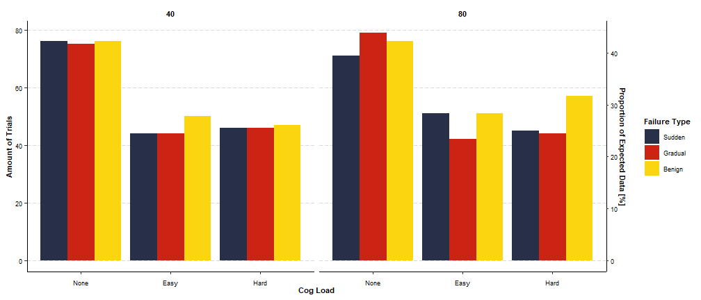

### Cognitive Load difficulty.

We only have the cognitive performance for baseline (without steering). Here we plot three indices of performance to assess whether our levels of cognitive difficulty are reflected in performance measures: *Percentage Correct* (PC, True positives + True negatives / total letters heard); *Reaction Time* (RT, reaction time for True positives); *Proportional Absolute Count Error* (average distance from the true count, expressed as a proportion of the total amount of targets heard).

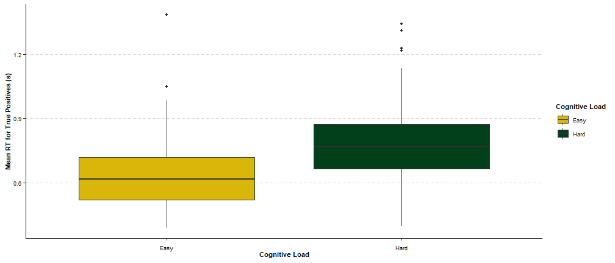

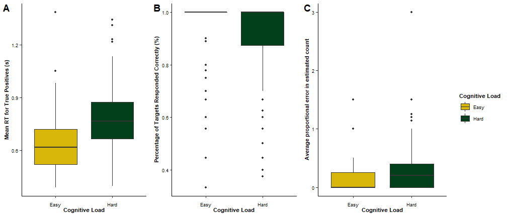

Fig 2 shows that people respond differently to each Cognitive Load condition. Participants react slower to heard target letters if they are listening for three targets rather than only one target (Fig 2A). Participants rarely make mistakes (i.e. responding to a distractor letter or not responding to a target letter) in the *Easy* Cognitive Load condition, they make more mistakes in the *Hard* Cognitive Load condition (Fig 2B).

The interpretation of the the count error (Fig 2C) is more nuanced. The total error (cumulative across all targets) is very similar across both conditions. How you use then use this total count error to take into account that people are responding to more targets in *Hard* than *Easy* is the debateable bit. For example, estimating five instead of six occurences (for one target) has the same total error as estimating zero, two, three, for target counts of one, two and three (for three targets). Yet one could argue that the two responses are qualitatively different because in the second case the participant has entirely missed a target but got the other two spot on. To reflect this I’ve chosen to express this measure as a proportional of the total amount of targets heard (Fig 2C). In any case, people are only marginally less accurate on this measure in the *Hard* cognitive load than for *Easy*. It seems that the more precise measures of RT and PC are better indicators of differences in performance.

Therefore, a quick eyeball of the baseline cognitive task performance suggests that people reacted slower and experienced greater difficulty in deciding the appropriate response when there were three targets as compared to when there was only one.

We will now see how this gets reflected in steering measures.

### Driver Takeover.

The pre-registration specifies two hypotheses relating to taking over control of the vehicle:

- **H1**: Participants will react slower to silent failures as cognitive load increases (i.e. more time will elapsed from the steering angle bias to the driver disengaging the automation).
- **H2**: Participants will react with less aggression as cognitive load increases, bringing the vehicle back to the centre more slowly (i.e. they will be smoother and make less corrections).

These two hypotheses will be analysed in turn.

#### H1: Speed of take-over

The pre-registration states that two measures will be calculated:

- RT from SAB onset to disengagement of the system via a button press (can be negative if they take over before the SAB is introduced). I will refer to this measure as RT<sub>takeover</sub>.
- RT from SAB onset to first steering movement (RT<sub>steer</sub>).

For the purposes of a ‘quick’ look at the pilot dataset I will only use RT<sub>takeover</sub> for now.

| ppid | radius | yawrate_offset | cogload | block | count | RT | disengaged | failure_type | premature |
| --- | --- | --- | --- | --- | --- | --- | --- | --- | --- |
| P01 | 40 | -9 | Hard | 0 | 3 | 0.5832418 | 1 | Sudden | 0 |
| P01 | 40 | -9 | Hard | 0 | 4 | 0.7165291 | 1 | Sudden | 0 |
| P01 | 40 | -9 | None | 1 | 1 | 0.5333023 | 1 | Sudden | 0 |
| P01 | 40 | -9 | None | 1 | 4 | -1.7000053 | 1 | Sudden | 1 |
| P01 | 40 | -9 | None | 2 | 1 | -6.4665087 | 1 | Sudden | 1 |
| P01 | 40 | -1.5 | Easy | 0 | 2 | 1.9498542 | 1 | Gradual | 0 |

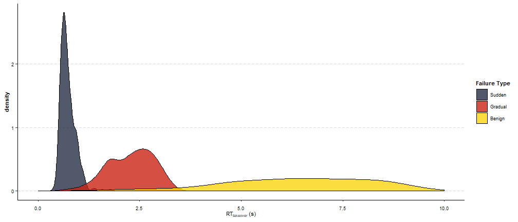

Fig 3 shows massive differences in how quickly drivers disengage the automation after SAB onset (using positive RTs only). In the *Benign* condition drivers disengaged the system in 43 % of trials. Since drivers react at such different speeds across the three failure types the failure type conditions will be plotted separately.

```
[1] 2.208198
```

Fig 5, below, plots RT<sub>takeover</sub> by bend radii for each failure type. Differences in RT<sub>takeover</sub> between bend radii, if there are any, appear small.

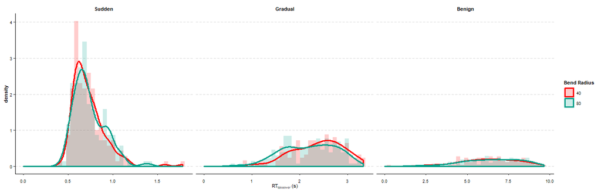

The next section will examine the steering response after takeover.

#### H2: Steering Response

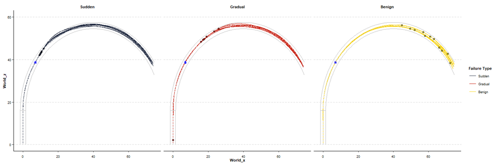

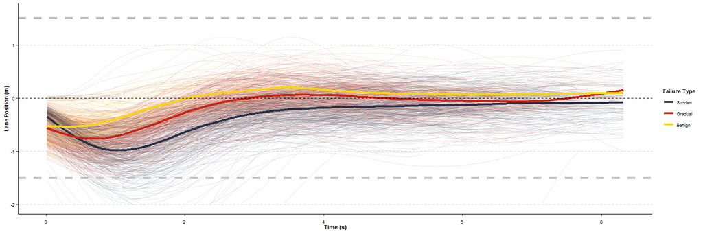

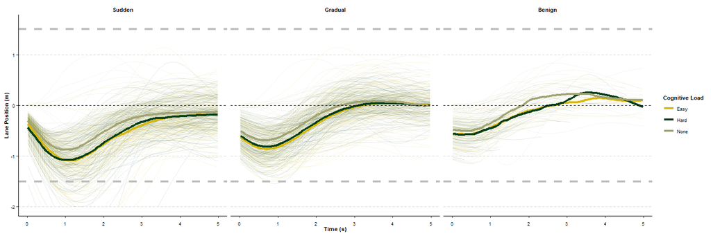

To disentangle whether the separation between average trajectories for ‘No Load’ and ‘Loaded’ conditions is due to less aggressive steering in the Cognitively loaded conditions we can take a look at the steering wheel angle plots over time (Fig 9). If the differences in lane position are *only* driven by delayed RTs we would expect the average SWA traces to be overlapping (i.e. on average, identical steering responses across cognitive load conditions irrespective of small changes in initial lane position). Conversely, we might also expect a reduced (in magnitude) or delayed steering wheel angle response in cognitive load conditions, as per Wilkie et al 2019.

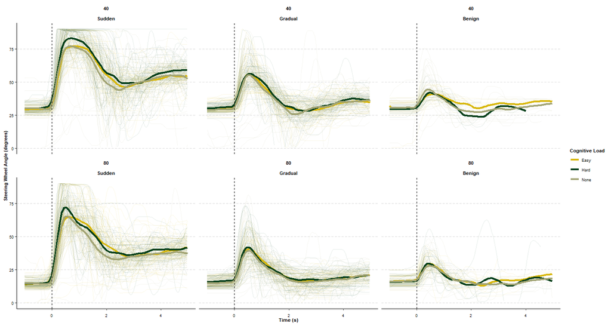

In no conditions do we see a convincing evidence of a reduced or delayed steering response when cognitively loaded (Fig 9). In *Benign* and *Gradual* failures (right and middle, Fig 9) the steering response seems pretty similar across cognitive load conditions, suggesting any separation in the steering bias plot could be due to reaction times.

The *Sudden* failures (left, Fig 9) require more description. The first thing to note is that the recorded steering wheel angle reaches the maximum yaw-rate. The steering wheel angle is not the true angle, it is re-calculated from a [1, -1] steering wheel value, which hits a limit at 90 degrees. Therefore, for many of the trials participants could be turning the wheel over the 90 degrees mark, yet the inputted yaw-rate into the simulation would be capped. This clearly happens for *Sudden* failures where there is need for a sharp turn. Despite the wheel angle capping, it is interesting that experiencing *Hard* cognitive load seems to cause greater wheel turns than *Easy* and *None*. It is probable that this is not due to an effect of cognitive load on *steering*. Rather, it could be the combined effect of slower RTs causing greater steering demand which cannot be wholly compensated due to the capped steering wheel angle. Indeed, disentangling the indirect effects of cognitive load on steering (from increasing RTs and therefore increasing steering demand) with the direct effects of cognitive load on steering will be difficult, as steering demands correlate with RTs. The next plot examines this issue by plotting three measures of steering aggression (SWA<sub>max</sub>, SWA<sub>var</sub>, and SWA<sub>vel</sub> next to RT<sub>takeover</sub>)

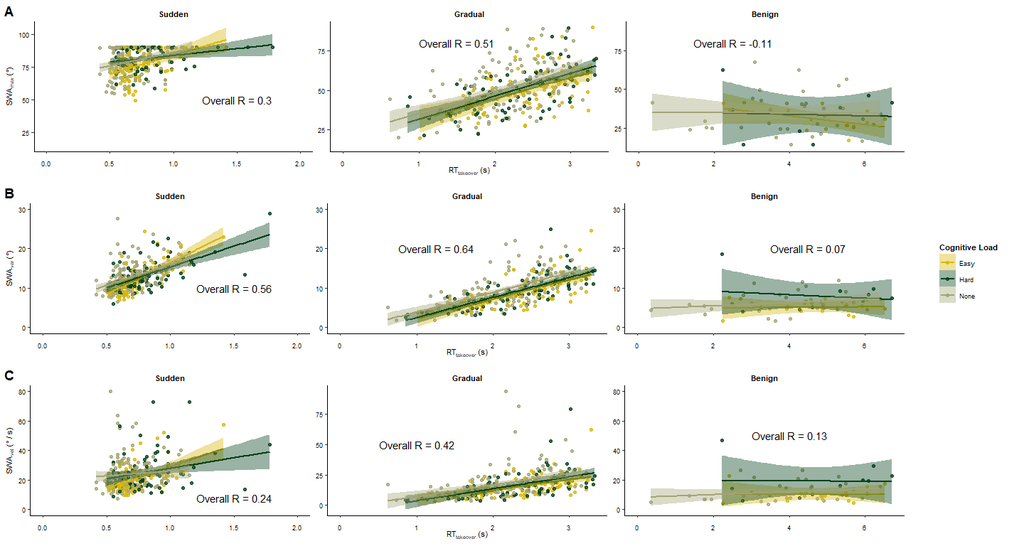

Fig 10 plots the maximum steering wheel angle (SWA<sub>max</sub>, Fig 10A) and the standard deviation of steering wheel angle (SWA<sub>var</sub>, Fig 10B), and the average steering wheel velocity (SWA<sub>vel</sub>) for the manual control period of driving. Only trials with at least three seconds of manual driving are plotted, since by this time most drivers have made their initial steering correction (see Fig 9). Trials can have a maximum of 15 seconds of driving. A higher SWA<sub>max</sub> would mean that the driver executed a sharper turn. A high SWA<sub>var</sub> is often considered a (bad) proxy for wiggly steering. The two measures are correlated since a higher SWA<sub>max</sub> usually indicates a higher SWA<sub>var</sub>. Steering wheel angle velocity is arguably a better measure for ‘jerkier’ steering as higher SWA<sub>vel</sub> values would mean a driver turned the wheel more rapidly, but in this particular dataset the measure is partly confounded by capping of the steering wheel angle, where velocity equals zero for the duration of time where the limit is hit.

**H2 Summary**: I will tentatively suggest that there does not appear to be practically significant direct effect of cognitive load on the aggression of the first steering response. I propose that RT<sub>takeover</sub> (which seems to fluctuate with cognitive load) is a stronger determinant of the strength of the first steering response.

### Summary so Far: what about the mechanism?

TO BE FINISHED ON WEDS 15TH…

Therefore, we recommend massively increasing the levels (e.g. ten levels) of silent failures so we have a decent breadth of SABs (and therefore TTCs) to fit models to. Only using one radii will increase the amount of levels we can assess. To ensure even coverage we will keep the design factorial, this means we can also do inferences on the data between conditions.

Jami has also suggested that we could look model cognitive load as reducing sampling rate. Worth pursuing and I think would mean keeping the cognitive load conditions…

Another design change is increasing sensitivity of the steering wheel to lift the capping confound of the wheel angles…

### Other Pre-registered Hypotheses

In the pre-registration there were three more hypotheses. Here I briefly list what we now know.

- **H3**: Participants will sample from a more constricted region of the screen for increased cognitive load.

*Not looked at yet, will look at if I have time before hols, but do not clearly see how this will change the design?*

- **H4**: These effects of cognitive load will increase as cognitive load difficulty increases.

*For sudden failures RT<sub>takeover</sub> appears to be stratified somewhat by Easy or Hard load. However, this effect is small, and smaller still (or nonexistent) in the less severe failures*.

- **H5**: Effects of cognitive load will become more pronounced when the (steering) task is more difficult (for sharp bends and sudden silent failures).

*There does not seem to be an interaction jumping out for bend radii. As stated above the small effects of cognitive load are more pronounced for silent failures*.